# Tarea Aplicaciones del Big Data en la empresa

2019-06-13

## **Grupo 7**

### Integrantes

#### - María Esther Arranz Sanz

#### - Beatriz González García

## **Introducción**

Para simular el análisis de datos que se llevaría a cabo en una empresa bajo la metodología Agile vamos a explicar en este documento los diferentes spring que hemos realizado hasta llegar al modelo ganador.

## **Datos**

Este análisis está basado en el dataset de Drivendata [Pump it Up: Data Mining the Water Table](https://www.drivendata.org/competitions/7/pump-it-up-data-mining-the-water-table/). El objetivo es predecir qué bombas de agua son funcionales, cuáles necesitan algunas reparaciones y cuáles no funcionan en absoluto. Los datos han sido recogidos en Tanzania.

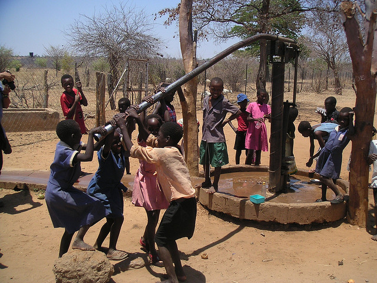

### Cargar los datos

Los datos a descargarse son los siguientes:

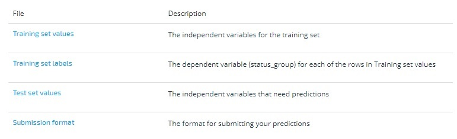

Los valores de los datos y las etiquetas están en archivos separados. Todos son en formato csv. Para cargar los datos utilizaremos el paquete

```r
library(data.table)
```

Importamos las etiquetas

```r
datLabel <-fread("01_labels.csv",nThread = 4)
```

Importamos los valores de los datos train

```r
datTrain <-fread("02_trainset.csv",nThread = 4)
```

Juntamos las etiquetas y sus valores

```r
datEnd <- merge(datTrain,datLabel,by.x="id",by.y = "id",all = TRUE)
```

### Estudio de los datos

Vemos las primeras observaciones

```r
head(datEnd)
```

```
##    id amount_tsh date_recorded          funder gps_height installer
## 1:  0          0    2012-11-13           Tasaf          0     TASAF
## 2:  1          0    2011-03-05           Shipo       1978     SHIPO
## 3:  2          0    2011-03-27            Lvia          0      LVIA
## 4:  3         10    2013-06-03 Germany Republi       1639       CES
## 5:  4          0    2011-03-22            Cmsr          0      CMSR
## 6:  5         50    2011-02-26         Private         28   Private
##    longitude  latitude       wpt_name num_private           basin
## 1:  33.12583 -5.118154        Mratibu           0 Lake Tanganyika
## 2:  34.77072 -9.395642           none           0          Rufiji
## 3:  36.11506 -6.279268        Bombani           0     Wami / Ruvu
## 4:  37.14743 -3.187555 Area 7 Namba 5           0         Pangani
## 5:  36.16489 -6.099289        Ezeleda           0     Wami / Ruvu
## 6:  39.28612 -6.972403      Kwa Namaj           0     Wami / Ruvu
##    subvillage      region region_code district_code      lga
```

[output cut: 55 more lines]

El significado de los campos es el siguiente

- *amount_tsh* - Total static head (amount water available to waterpoint)
- *date_recorded* - The date the row was entered
- *funder* - Who funded the well
- *gps_height* - Altitude of the well
- *installer* - Organization that installed the well
- *longitude* - GPS coordinate
- *latitude* - GPS coordinate
- *wpt_name* - Name of the waterpoint if there is one
- *num_private* -
- *basin* - Geographic water basin
- *subvillage* - Geographic location
- *region* - Geographic location
- *region_code* - Geographic location (coded)
- *district_code* - Geographic location (coded)
- *lga* - Geographic location
- *ward* - Geographic location
- *population* - Population around the well
- *public_meeting* - True/False
- *recorded_by* - Group entering this row of data
- *scheme_management* - Who operates the waterpoint
- *scheme_name* - Who operates the waterpoint
- *permit* - If the waterpoint is permitted
- *construction_year* - Year the waterpoint was constructed
- *extraction_type* - The kind of extraction the waterpoint uses
- *extraction_type_group* - The kind of extraction the waterpoint uses
- *extraction_type_class* - The kind of extraction the waterpoint uses
- *management* - How the waterpoint is managed
- *management_group* - How the waterpoint is managed
- *payment* - What the water costs
- *payment_type* - What the water costs
- *water_quality* - The quality of the water
- *quality_group* - The quality of the water
- *quantity* - The quantity of water
- *quantity_group* - The quantity of water
- *source* - The source of the water
- *source_type* - The source of the water
- *source_class* - The source of the water
- *waterpoint_type* - The kind of waterpoint
- *waterpoint_type_group* - The kind of waterpoint

La variable objetivo es status_group y toma tres posibles valores

- *functional* - the waterpoint is operational and there are no repairs needed
- *functional needs repair* - the waterpoint is operational, but needs repairs
- *non functional* - the waterpoint is not operational

Para ver la distribución de la variable objetivo utilizamos los paquetes

```r
library(dplyr)
```

```r
library(ggplot2)
```

Vemos que está muy desbalanceada

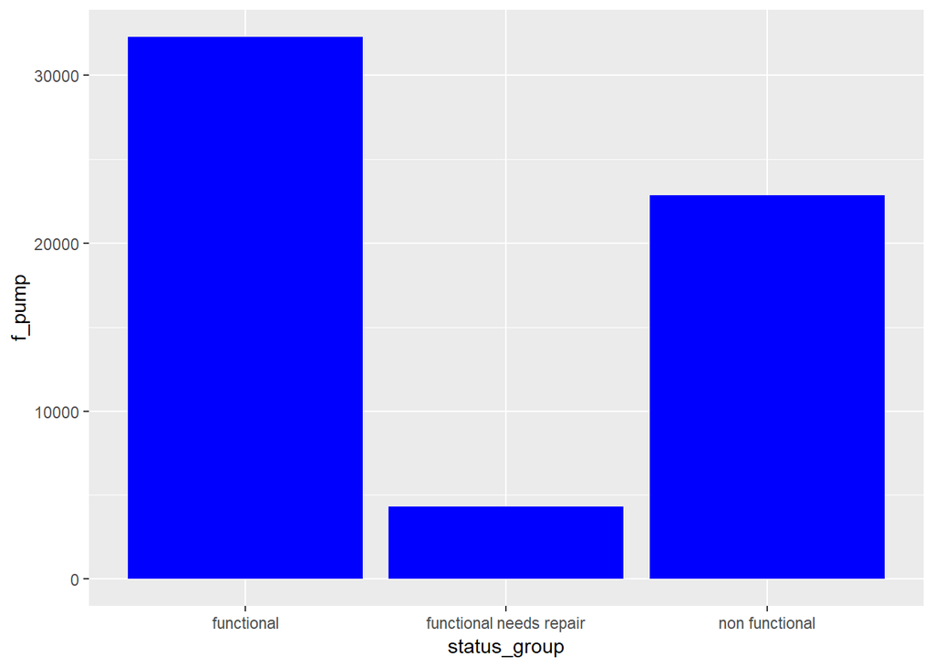

```r
datEnd %>%
  select(status_group) %>%
  group_by(status_group) %>%
  summarise(f_pump = n())%>%
  arrange(desc(f_pump)) %>%
  ggplot(aes(status_group, f_pump)) +
  geom_col(fill= 'blue')
```

Para conocer las clases de las variables

```r
as.data.frame(mapply(class, datEnd))
```

```
##                       mapply(class, datEnd)
## id                                  integer
## amount_tsh                          numeric
## date_recorded                     character
## funder                            character
## gps_height                          integer
## installer                         character
## longitude                           numeric
## latitude                            numeric
## wpt_name                          character
## num_private                         integer
## basin                             character
## subvillage                        character
## region                            character
## region_code                         integer
## district_code                       integer
## lga                               character
## ward                              character
## population                          integer
## public_meeting                      logical
## recorded_by                       character
## scheme_management                 character
## scheme_name                       character
## permit                              logical
## construction_year                   integer
## extraction_type                   character
## extraction_type_group             character
## extraction_type_class             character
## management                        character
## management_group                  character
## payment                           character
## payment_type                      character
## water_quality                     character
## quality_group                     character
## quantity                          character
## quantity_group                    character
## source                            character
## source_type                       character
## source_class                      character
## waterpoint_type                   character
## waterpoint_type_group             character
## status_group                      character
```

Las categorías de las variables numéricas

```r
sapply(Filter(is.numeric, datEnd), function(x)length(unique(x)))
```

```
##                id        amount_tsh        gps_height         longitude
##             59400                98              2428             57516
##          latitude       num_private       region_code     district_code
##             57517                65                27                20
##        population construction_year
##              1049                55
```

```r
sapply(Filter(is.integer, datEnd), function(x)length(unique(x)))
```

```
##                id        gps_height       num_private       region_code
##             59400              2428                65                27
##     district_code        population construction_year
##                20              1049                55
```

Y para las variables de tipo character

```r
sapply(Filter(is.character, datEnd), function(x)length(unique(x)))
```

```
##         date_recorded                funder             installer
##                   356                  1898                  2146
##              wpt_name                 basin            subvillage
##                 37400                     9                 19288
##                region                   lga                  ward
##                    21                   125                  2092
##           recorded_by     scheme_management           scheme_name
##                     1                    13                  2697
##       extraction_type extraction_type_group extraction_type_class
##                    18                    13                     7
##            management      management_group               payment
##                    12                     5                     7
##          payment_type         water_quality         quality_group
##                     7                     8                     6
##              quantity        quantity_group                source
##                     5                     5                    10
##           source_type          source_class       waterpoint_type
##                     7                     3                     7
## waterpoint_type_group          status_group
##                     6                     3
```

Con summary obtenemos más información de los datos

```r
summary(datEnd)
```

```
##        id          amount_tsh       date_recorded         funder
##  Min.   :    0   Min.   :     0.0   Length:59400       Length:59400
##  1st Qu.:18520   1st Qu.:     0.0   Class :character   Class :character
##  Median :37062   Median :     0.0   Mode  :character   Mode  :character
##  Mean   :37115   Mean   :   317.7
##  3rd Qu.:55657   3rd Qu.:    20.0
##  Max.   :74247   Max.   :350000.0
##    gps_height      installer           longitude        latitude
##  Min.   : -90.0   Length:59400       Min.   : 0.00   Min.   :-11.649
##  1st Qu.:   0.0   Class :character   1st Qu.:33.09   1st Qu.: -8.541
##  Median : 369.0   Mode  :character   Median :34.91   Median : -5.022
##  Mean   : 668.3                      Mean   :34.08   Mean   : -5.706
##  3rd Qu.:1319.2                      3rd Qu.:37.18   3rd Qu.: -3.326
##  Max.   :2770.0                      Max.   :40.35   Max.   :  0.000
##    wpt_name          num_private           basin
##  Length:59400       Min.   :   0.0000   Length:59400
##  Class :character   1st Qu.:   0.0000   Class :character
##  Mode  :character   Median :   0.0000   Mode  :character
##                     Mean   :   0.4741
##                     3rd Qu.:   0.0000
##                     Max.   :1776.0000
##   subvillage           region           region_code   district_code
##  Length:59400       Length:59400       Min.   : 1.0   Min.   : 0.00
##  Class :character   Class :character   1st Qu.: 5.0   1st Qu.: 2.00
##  Mode  :character   Mode  :character   Median :12.0   Median : 3.00
##                                        Mean   :15.3   Mean   : 5.63
##                                        3rd Qu.:17.0   3rd Qu.: 5.00
##                                        Max.   :99.0   Max.   :80.00
##      lga                ward             population      public_meeting
##  Length:59400       Length:59400       Min.   :    0.0   Mode :logical
##  Class :character   Class :character   1st Qu.:    0.0   FALSE:5055
##  Mode  :character   Mode  :character   Median :   25.0   TRUE :51011
##                                        Mean   :  179.9   NA's :3334
##                                        3rd Qu.:  215.0
##                                        Max.   :30500.0
##  recorded_by        scheme_management  scheme_name          permit
##  Length:59400       Length:59400       Length:59400       Mode :logical
##  Class :character   Class :character   Class :character   FALSE:17492
##  Mode  :character   Mode  :character   Mode  :character   TRUE :38852
##                                                           NA's :3056
```

[output cut: 29 more lines]

```
##
##     source          source_type        source_class
##  Length:59400       Length:59400       Length:59400
##  Class :character   Class :character   Class :character
##  Mode  :character   Mode  :character   Mode  :character
##
##
##
##  waterpoint_type    waterpoint_type_group status_group
##  Length:59400       Length:59400          Length:59400
##  Class :character   Class :character      Class :character
##  Mode  :character   Mode  :character      Mode  :character
##
##
##
```

## MODELOS

### **Sprint 1**

Para un primer modelo de árbol con las variables numéricas se usa el paquete ranger

```r
library(ranger)
```

Este paquete necesita que la variable objetivo esté como un factor. El modelo es:

```r
my_mod1 <- ranger(
  as.factor(status_group) ~ id + gps_height + num_private + region_code +
    district_code +  population + construction_year + longitude + latitude + amount_tsh,
  data = datEnd, importance = 'impurity'
)
```

Para hacer una predicción sobre el modelo utilizamos el paquete caret

```r
library(caret)
```

La predicción obtenida es:

```r
pred_mod <- predict(my_mod1, datEnd)
```

La importancia de las variables en el modelo:

```r
as.data.frame(importance(my_mod1))
```

```
##                   importance(my_mod1)
## id                         2654.40909
## gps_height                 3112.91450
## num_private                  81.99803
## region_code                 893.86679
## district_code               951.15872
## population                 2201.88486
## construction_year          2635.51682
## longitude                  4571.28809
## latitude                   4455.13149
## amount_tsh                 1728.28202
```

Y la matriz de confusión es:

```r
confusionMatrix(pred_mod$predictions,as.factor(datEnd$status_group))
```

```
## Confusion Matrix and Statistics
##
##                          Reference
## Prediction                functional functional needs repair
##   functional                   31120                    1366
##   functional needs repair         10                    2674
##   non functional                1129                     277
##                          Reference
## Prediction                non functional
##   functional                        4239
##   functional needs repair             21
##   non functional                   18564
##
## Overall Statistics
##
##                Accuracy : 0.8814
##                  95% CI : (0.8788, 0.884)
##     No Information Rate : 0.5431
##     P-Value [Acc > NIR] : < 2.2e-16
##
##                   Kappa : 0.777
##
##  Mcnemar's Test P-Value : < 2.2e-16
##
## Statistics by Class:
##
##                      Class: functional Class: functional needs repair
## Sensitivity                     0.9647                        0.61941
## Specificity                     0.7935                        0.99944
## Pos Pred Value                  0.8474                        0.98854
## Neg Pred Value                  0.9498                        0.97102
## Prevalence                      0.5431                        0.07268
## Detection Rate                  0.5239                        0.04502
## Detection Prevalence            0.6183                        0.04554
## Balanced Accuracy               0.8791                        0.80942
##                      Class: non functional
## Sensitivity                         0.8134
## Specificity                         0.9616
## Pos Pred Value                      0.9296
## Neg Pred Value                      0.8920
## Prevalence                          0.3842
## Detection Rate                      0.3125
## Detection Prevalence                0.3362
## Balanced Accuracy                   0.8875
```

Para hacer la submission del modelo primero transformamos el archivo test en un data.frame para luego usarlo en el modelo que hemos creado

```r
test <- as.data.frame(fread("03_Testset.csv",nThread = 3))
```

Obtenemos la predicción de nuestro modelo para cada fila del archivo test que es sobre el que hay que probar nuestro modelo

```r
pred_test <- as.vector(predict(my_mod1, test)$prediction)
```

Creamos nuestro submission para lo que necesitamos el id y lo hacemos en un dataframe

```r
my_sub <- data.frame(
          id = test$id,
          status_group = pred_test
)
```

Lo guardamos en un archivo con el nombre del modelo1 para tenerlos controlados

```r
fwrite(my_sub, file="sub_v01_base.csv", sep =",")
```

Y el resultado de la submission

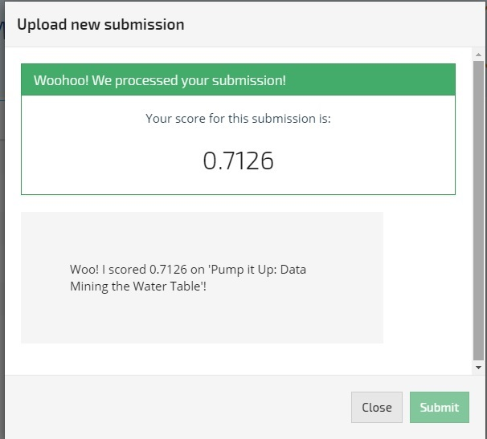

### **Sprint 2**

Hacemos un segundo modelo utilizando el paquete dataPreparation

```r
library(dataPreparation)
```

Lo primero que hacemos en coger los datos train y eliminar la variable objetivo

```r
nuevo <- as.data.frame(datEnd[,-c(41)])
```

Juntamos los datos train y test

```r
datprep <- rbind(nuevo, test)
```

Ahora utilizamos la función prepareSet para preparar los datos

```r
clean_datprep <- prepareSet(datprep)
```

[output not shown]

[output cut: 53 more lines]

Separamos los datos train de test e incluimos la variable objetivo de los datos originales

```r
train <- clean_datprep[c(1:59400),]
train$status_group <- datEnd$status_group
```

Volvemos a utilizar ranger para el modelo2:

```r
my_mod2 <- ranger(
  as.factor(status_group) ~.,
  data = train, importance = 'impurity'
)
```

Para hacer una predicción sobre el modelo utilizamos el paquete caret

```r
library(caret)
```

La predicción obtenida es:

```r
pred_mod2 <- predict(my_mod2, train)
```

La importancia de las variables en el modelo2:

```r
as.data.frame(importance(my_mod2))
```

```
##                           importance(my_mod2)
## id                                2977.353062
## amount_tsh                         396.892065
## gps_height                        1667.039391
## longitude                         2338.679804
## latitude                          2352.706600
## num_private                         38.476392
## region_code                        231.685607
## district_code                      280.500932
## population                        1216.353305
## public_meeting                     126.675975
## permit                             129.984130
## construction_year                  756.180538
## date.recorded.yearmonth            432.113229
## funder.notnull                      18.859894
## funder.num                         650.829716
## funder.order                       656.422847
## installer.notnull                   18.796241
## installer.num                      566.495496
## installer.order                    584.029952
## wpt.name.num                      1062.261923
## wpt.name.order                    2477.699525
## basin.num                          232.226739
## subvillage.notnull                   3.556896
## subvillage.num                    1518.321640
## subvillage.order                  2086.231182
## region.num                         225.579731
## lga.num                            396.179396
## lga.order                          394.078905
## ward.num                           967.331367
## ward.order                        1040.809599
## scheme.management.notnull           38.199196
## scheme.management.num              245.627249
## scheme.name.notnull                 73.487107
## scheme.name.num                    595.181536
## scheme.name.order                  632.697342
## extraction.type.num                298.311369
## extraction.type.group.num          287.330834
## extraction.type.class.num          179.889960
## management.num                     238.414382
## management.group.num               117.468700
## payment.num                        423.506682
## water.quality.num                  174.724531
## quality.group.num                  162.612266
## quantity.group.num                 414.785661
## source.num                         230.765311
## source.type.num                    204.989714
## source.class.num                    71.800012
## waterpoint.type.num                211.932269
## waterpoint.type.group.num           76.348641
```

Y la matriz de confusión es:

```r
confusionMatrix(pred_mod2$predictions,as.factor(train$status_group))
```

```
## Confusion Matrix and Statistics
##
##                          Reference
## Prediction                functional functional needs repair
##   functional                   32248                      76
##   functional needs repair          0                    4217
##   non functional                  11                      24
##                          Reference
## Prediction                non functional
##   functional                          58
##   functional needs repair              0
##   non functional                   22766
##
## Overall Statistics
##
##                Accuracy : 0.9972
##                  95% CI : (0.9967, 0.9976)
##     No Information Rate : 0.5431
##     P-Value [Acc > NIR] : < 2.2e-16
##
##                   Kappa : 0.9948
##
##  Mcnemar's Test P-Value : < 2.2e-16
##
## Statistics by Class:
##
##                      Class: functional Class: functional needs repair
## Sensitivity                     0.9997                        0.97684
## Specificity                     0.9951                        1.00000
## Pos Pred Value                  0.9959                        1.00000
## Neg Pred Value                  0.9996                        0.99819
## Prevalence                      0.5431                        0.07268
## Detection Rate                  0.5429                        0.07099
## Detection Prevalence            0.5452                        0.07099
## Balanced Accuracy               0.9974                        0.98842
##                      Class: non functional
## Sensitivity                         0.9975
## Specificity                         0.9990
## Pos Pred Value                      0.9985
## Neg Pred Value                      0.9984
## Prevalence                          0.3842
## Detection Rate                      0.3833
## Detection Prevalence                0.3839
## Balanced Accuracy                   0.9983
```

Los datos test son

```r
tst <- clean_datprep[-c(1:59400),]
```

Obtenemos la predicción de nuestro modelo2 para probar el modelo2

```r
pred_test <- as.vector(predict(my_mod2, tst)$prediction)
```

Creamos nuestro submission para lo que necesitamos el id y lo hacemos en un dataframe

```r
my_sub <- data.frame(
          id = test$id,
          status_group = pred_test
)
```

```r
fwrite(my_sub, file="sub_v02_base.csv", sep =",")
```

Y el resultado de la submission

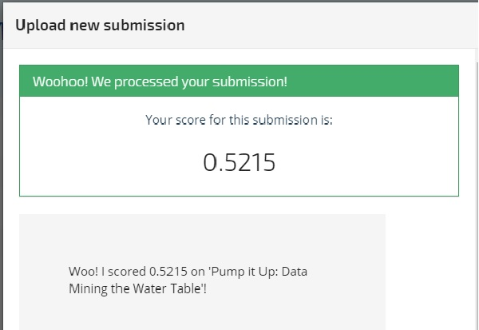

Algo no hemos hecho bien, un Accuracy tan alto debería habernos dado alguna pista…

### **Sprint 3**

Para el modelo final utilizamos el archivo creado en un modelo intermedio para ver las categorías de las variables.

```r
var_tp<- as.data.frame(fread("datos_desc.csv",nThread = 3))
var_tp
```

```
##         tipo dist_count
## 1    integer      59400
## 2    numeric         98
## 3  character        356
## 4  character       1898
## 5    integer       2428
## 6  character       2146
## 7    numeric      57516
## 8    numeric      57517
## 9  character      37400
## 10   integer         65
## 11 character          9
## 12 character      19288
## 13 character         21
## 14   integer         27
```

[output cut: 27 more lines]

Ahora se separan las variables en:

```r
var_y<- c("status_group")
```

- Variables numéricas

```r
var_num<- c("id", "amount_tsh", "gps_height", "longitude", "latitude",
            "num_private", "region_code", "district_code", "population",
            "construction_year")
```

```r
var_catlte15<- c("basin", "public_meeting", "recorded_by", "scheme_management",
                 "permit", "extraction_type_group", "extraction_type_class", "management",
                 "management_group", "payment", "payment_type", "water_quality",
                 "quality_group", "quantity", "quantity_group", "source", "source_type",
                 "source_class", "waterpoint_type", "waterpoint_type_group", "status_group")
```

```r
var_catgt15<-c("date_recorded", "funder", "installer", "wpt_name", "subvillage",
               "region", "lga", "ward", "scheme_name", "extraction_type")
```

- Variables NA

```r
var_nas<- c("public_meeting", "permit")
```

- Variable a eliminar porque tiene el mismo valor para todas las observaciones

```r
var_shit<- c("recorded_by")
```

Ahora se utilizan los siguientes datos

```r
datEnd<- as.data.frame(readRDS("datEnd.rds"))
datJoin<- as.data.frame(fread("datJoin.csv"))
```

Se hace una selección de variables

```r
var_add<- names(datJoin)[!(names(datJoin) %in% names(datEnd))]
var_sel<- names(datJoin)[names(datJoin) %in% c(var_num, var_catlte15, var_nas, var_add)]
```

Se convierte la variable input en números

```r
# Fit var_y (3 categories)
y<- datEnd[,var_y]
y_better<- ifelse(y=="functional",1,
                  ifelse(y=="non functional", 0, 2))
```

Separa datos train de test

```r
# Train - Test split
datTrain<- datJoin[seq(1, nrow(datEnd)), var_sel]
datTrain$y<- as.factor(make.names(y_better))
datTest<- datJoin[seq(nrow(datEnd)+1,nrow(datJoin)),var_sel]
```

Modelo ranger

```r
# Ranger Model
frml<- as.formula(paste("y~", paste(var_sel, collapse="+")))
set.seed(123)
control<-trainControl(method = "LGOCV",
                      p=0.8, number=1, savePredictions = "all",
                      classProbs=TRUE)
rgr<- ranger(frml, datTrain,
             num.trees = 100, importance="impurity",
             write.forest = T, splitrule = "extratrees",
             num.random.splits = 10)
mod<- rgr
```

La predicción y el submission

```r
# Predictions
pred_train<- as.vector(predict(mod, datTrain)$predictions)
length(which(pred_train==datTrain$y))/nrow(datTrain)
```

```
## [1] 0.9519865
```

```r
pred_test<- as.vector(predict(mod, datTest)$predictions)
pred_test<- ifelse(pred_test=="X1","functional",
                   ifelse(pred_test=="X0","non functional","functional needs repair"))
my_sub<- data.frame(
    id = test$id,
    status_group = pred_test
)
head(my_sub)
```

```
##      id   status_group
## 1 50785     functional
## 2 51630     functional
## 3 17168     functional
## 4 45559 non functional
## 5 49871     functional
## 6 52449     functional
```

```r
fwrite(my_sub, "sub_V8_base.csv", sep=",")
```

Y el resultado de la submission

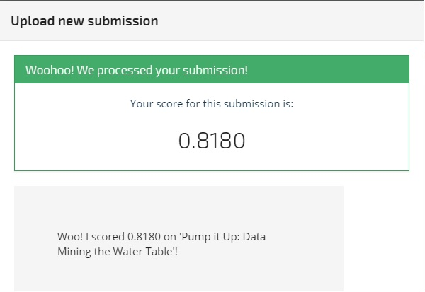

Y en la clasificación general

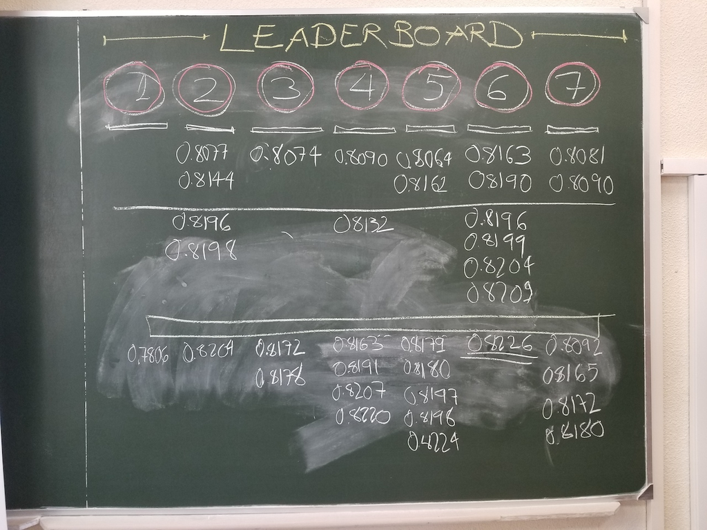

**FELICIDADES A LOS GANADORES!!!**